# Tables at Grattan

2024-02-14

## Objectives

In this session you will learn to:

- Create summary tables in R
- Convert R tables into a LaTeX format with the **knitr** and **kableExtra** packages
- Save LaTeX tables directly into Overleaf

## Getting started with R tables

## Let’s load our packages

## The pizzaplace dataset

Dataset contains 2015 sales data for a pizzeria, where each row is a pizza sold.

```r
pizzaplace |>
  str(vec.len = 3) # Just show first 3 values
```

```
## tibble [49,574 × 7] (S3: tbl_df/tbl/data.frame)
##  $ id   : chr [1:49574] "2015-000001" "2015-000002" "2015-000002" ...
##  $ date : chr [1:49574] "2015-01-01" "2015-01-01" "2015-01-01" ...
##  $ time : chr [1:49574] "11:38:36" "11:57:40" "11:57:40" ...
##  $ name : chr [1:49574] "hawaiian" "classic_dlx" "mexicana" ...
##  $ size : chr [1:49574] "M" "M" "M" ...
##  $ type : chr [1:49574] "classic" "classic" "veggie" ...
##  $ price: num [1:49574] 13.2 16 16 20.8 ...
```

## Summary tables

To get the number of pizzas sold of different types, we can use the table function.

```r
freq_table <- table(pizzaplace$type)

print(freq_table)
```

```
##
## chicken classic supreme  veggie
##   11050   14888   11987   11649
```

If we want relative proportions, not a frequency table, we can use prop.table().

```r
prop.table(freq_table)
```

```
##
##   chicken   classic   supreme    veggie
## 0.2228991 0.3003187 0.2418001 0.2349820
```

## Two-way frequency tables

We can also make two-way frequency tables in base R.

```r
two_way_table <- table(pizzaplace$type, pizzaplace$size) |>
  # We convert the table to a data frame as relocate
  # does not work on a table object
  as.data.frame.matrix() |>
  relocate(c(S, M), .before = L)

print(two_way_table)
```

```
##            S    M    L  XL XXL
## chicken 2224 3894 4932   0   0
## classic 6139 4112 4057 552  28
## supreme 3377 4046 4564   0   0
## veggie  2663 3583 5403   0   0
```

No way! Vegetarians can’t get big pizzas. This is an outrage.

We can get more fancy using other packages.

- Use `tabyl()` from **janitor** to produce and “adorn” tabulations and cross-tabulations
- Use `get_summary_stats()` from **rstatix** to easily generate data frames of numeric summary statistics for multiple columns and/or groups
- Use `summarise()` and `count()` from **dplyr** for more complex statistics, tidy data frame outputs, or preparing data for ggplot()
- Use `tbl_summary()` from **gtsummary** to produce detailed publication-ready tables

## From R to LaTeX

### How to get your tables report-ready

## The **kable** package

The **knitr** and **kableExtra** packages allows you to produce report-ready tables.

Let’s begin by piping our table into the `kable()` function.

```r
two_way_table |>
  kable() |>
  kable_styling(full_width = T)
```

|  | S | M | L | XL | XXL |
| --- | --- | --- | --- | --- | --- |
| chicken | 2224 | 3894 | 4932 | 0 | 0 |
| classic | 6139 | 4112 | 4057 | 552 | 28 |
| supreme | 3377 | 4046 | 4564 | 0 | 0 |
| veggie | 2663 | 3583 | 5403 | 0 | 0 |

We can see that it already looks visually better.

We can also add arguments within the the `kable()` call

```r
pretty_table <-
  two_way_table %>%
  # Capitalising the pizza types (which are saved as labels)
  mutate(Type = labels(.)[[1]] |> str_to_sentence(), .before = S) |>
  # This line removes the original labels
  unnest() |>
  # I've added totals for each type, too, using the <b>janitor<\b> package
  janitor::adorn_totals(where = "col")
```

Size doesn’t really matter

| Type | S | M | L | XL | XXL | Total |
| --- | --- | --- | --- | --- | --- | --- |
| Chicken | 2,224 | 3,894 | 4,932 | 0 | 0 | 11,050 |
| Classic | 6,139 | 4,112 | 4,057 | 552 | 28 | 14,888 |
| Supreme | 3,377 | 4,046 | 4,564 | 0 | 0 | 11,987 |
| Veggie | 2,663 | 3,583 | 5,403 | 0 | 0 | 11,649 |

Source: Pizzeria sales, 2015.

## Getting jazzy

We can even format the table columns and add small plots.

```r
final_table <- pretty_table |>
  cbind(`Sales over time` = "") |>
  kable(booktabs = T) |>
  kable_styling(full_width = T) |>
  # Make the first column bold
  column_spec(1, bold = T) |>
  # Add a gradient to the totals column,
  # proportionate to background fill
  column_spec(7,
    color = "white",
    italic = T,
    background = spec_color(pretty_table$Total, end = 0.7)
  ) |>
  # Add inline plots to the final column
  column_spec(8, image = spec_plot(price_list))
```

Here is what the final product looks like

| Type | S | M | L | XL | XXL | Total | Sales over time |
| --- | --- | --- | --- | --- | --- | --- | --- |
| Chicken | 2224 | 3894 | 4932 | 0 | 0 | 11050 |  |
| Classic | 6139 | 4112 | 4057 | 552 | 28 | 14888 |  |
| Supreme | 3377 | 4046 | 4564 | 0 | 0 | 11987 |  |
| Veggie | 2663 | 3583 | 5403 | 0 | 0 | 11649 |  |

## Exporting to Latex

### How to get your pretty table into LaTeX

## Exporting

Use `writeLines` to save a `.tex` file with your Tex code. I save it straight to Overleaf.

```r
final_table |>
  writeLines(paste0("C:/Users/parkinsonn/Dropbox (Grattan Institute)",
                  "/Apps/Overleaf/",
                  "tables-at-grattan/tables/tbl_pizza_sales.tex"))
```

## Add the table to your report

Use the `\input{tables\your_table.text}` in Overleaf to call your table.

You may wish to make the table fit a full column by changing the table environment to `\begin{tabularx}` and adding `{\linewidth}`.

You may need to adjust column widths. This can be done back in R. To make the first column 2cm wide, use `column_spec(1, width = "2cm")`.

## And voilà

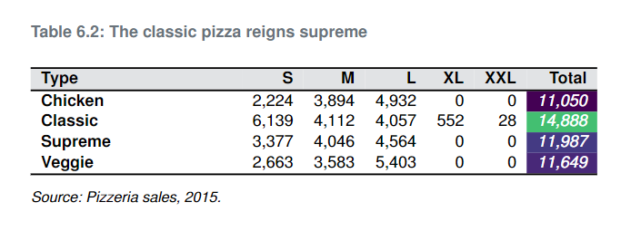